```python
from IPython.display import HTML

HTML('''<script>
code_show=true;
function code_toggle() {
 if (code_show){
 $('div.input').hide();
 } else {
 $('div.input').show();
 }
 code_show = !code_show
}
$( document ).ready(code_toggle);
</script>
<form action="javascript:code_toggle()"><input type="submit" value="Click to toggle on/off the code."></form>''')
```

```python
import os
from IPython.display import Image, display

if not os.path.exists("images"):
    os.mkdir("images")

inPNG = True
imheight = 450
imwidth = 900
imscale = 3
```

```python
%run ./import_data.ipynb

cf.set_config_file(dimensions=(imwidth,imheight))

# make copy of the raw DB
df19_init = df19.copy()
df20_init = df20.copy()

# Shifted data with all values
df19["Datetime"] = pd.to_datetime(df19.index + timedelta(days=365-1))
df19.set_index('Datetime', inplace=True)
dfHDD19["Datetime"] = pd.to_datetime(dfHDD19.index + timedelta(days=365-1+7))
dfHDD19.set_index('Datetime', inplace=True)
dfHDD20["Datetime"] = pd.to_datetime(dfHDD20.index + timedelta(days=7))
dfHDD20.set_index('Datetime', inplace=True)

df20["Datetime"] = pd.to_datetime(df20.index)
df20.set_index('Datetime', inplace=True)
alldf = df19[['LOAD19','TEMP19','PEN19']]
alldf = alldf.merge(df20[['LOAD20','TEMP20','PEN20']], left_index=True, right_index=True)
# Focus on specific area
alldf = alldf[(alldf.index.weekofyear >= 10) & (alldf.index.weekofyear <= 17)]
dfHDD19 = dfHDD19[(dfHDD19.index.weekofyear >= 10) & (dfHDD19.index.weekofyear <= 17)]
dfHDD20 = dfHDD20[(dfHDD20.index.weekofyear >= 10) & (dfHDD20.index.weekofyear <= 17)]

allHDD = dfHDD20
allHDD.rename(columns={'HDD': 'HDD20'}, inplace=True)
allHDD['HDD19'] = dfHDD19['HDD']
allHDD['HDDDIFF'] = allHDD['HDD20'] - allHDD['HDD19']

# Shifted data without weekends and other holidays only weeks 12 to 17
removelist = ['2019-03-02', '2020-03-25','2020-04-01','2020-04-17',
              '2020-04-20','2019-03-11','2019-03-25','2019-04-01',
              '2019-04-26','2019-04-29']
df19wd = df19_init[[d.date() not in pd.to_datetime(removelist) for d in df19_init.index]]
df19wd = df19wd[ (df19wd.index.weekofyear >= 12) & (df19wd.index.weekofyear <= 17) & (df19wd.index.weekday < 5) ]
df20wd = df20_init[[d.date() not in pd.to_datetime(removelist) for d in df20_init.index]]
df20wd = df20wd[ (df20wd.index.weekofyear >= 12) & (df20wd.index.weekofyear <= 17) & (df20wd.index.weekday < 5) ]
```

# Η επίδραση του κορονοϊού στην ενεργειακή συμπεριφορά των Κυπρίων

Οι συνθήκες πανδημίας και τα μέτρα που επέβαλε η κυβέρνηση για να περιορίσει την εξάπλωση του COVID19, έχουν μεγάλες επιπτώσεις στον τρόπο ζωής όλων των Κύπριων. Η οικονομική δραστηριότητα έχει μειωθεί δραματικά με μια μεγάλη μερίδα του πληθυσμού να δουλεύει από το σπίτι. Τα σχολεία έχουν κλείσει και οι μαθητές ακολουθούν εξ αποστάσεως εκπαίδευση. Πολλές εταιρίες αναγκάστηκαν σε χρόνο ρεκόρ να αλλάξουν τα επιχειρηματικά τους μοντέλα για να επιβιώσουν.

Ενώ όλοι βιώνουμε τις αλλαγές αυτές, είναι πολύ δύσκολο να ποσοτικοποιήσουμε τον άμεσο τους αντίκτυπο πάνω στην οικονομία και την καθημερινότητά μας. Η ενεργειακή συμπεριφορά, και πιο συγκεκριμένα η κατανάλωση ηλεκτρικής ενέργειας μπορεί να αποτελέσει ένα δείκτη πραγματικού χρόνου που μεταφράζει τη νέα αυτή πραγματικότητα σε αριθμούς.

Είναι γνωστό ότι η κατανάλωση ηλεκτρικής ενέργειας είναι άρρηκτα συνδεδεμένη με την οικονομική δραστηριότητα αλλά και με διάφορους δείκτες ποιότητας ζωής, όπως η υγεία και η παιδεία. Αναλύοντας τον χρόνο, τη διάρκεια, αλλά και την ποσότητα ηλεκτρικής ενέργειας που καταναλώνεται στη Κύπρο, μπορούμε να εξαγάγουμε χρήσιμα συμπεράσματα. Αντίθετα με άλλους δείκτες οικονομικής ή κοινωνικής δραστηριότητας, τα δεδομένα παραγωγής ηλεκτρικής ενέργειας, καθώς και ιστορικά δεδομένα, είναι διαθέσιμα άμεσα και σε πραγματικό χρόνο στην ιστοσελίδα του [Διαχειριστή Συστήματος Μεταφοράς Κύπρου](https://tsoc.org.cy/). Σ ’αυτό το άρθρο αναλύουμε αυτά τα δεδομένα με σκοπό την εξαγωγή κάποιων δεικτών οι οποίοι αντικατοπτρίζουν τη μεταβολή της ενεργειακής συμπεριφοράς στην Κύπρο.

## Επιπτώσεις στη κατανάλωση ηλεκτρικής ενέργειας

Ο πρώτος δείκτης ο οποίος δύναται να περιγράψει τη μεταβολή στην οικονομική δραστηριότητα, είναι η εβδομαδιαία μέση κατανάλωση ηλεκτρικής ενέργειας κατά τις εργάσιμες μέρες και ώρες (Εικόνα 1). Διαβλέπουμε ξεκάθαρα τη ραγδαία μείωση στην κατανάλωση ηλεκτρικής ενέργειας από την πρώτη εβδομάδα εφαρμογής των μέτρων. Η μείωση συνεχίζει όλη την περίοδο, φτάνοντας σε ιστορικά χαμηλές τιμές. Στην ίδια εικόνα βλέπουμε την αντίστοιχη κατανάλωση της περσινής χρονιάς για σκοπούς σύγκρισης, - με ανάλογες προσαρμογές- ώστε οι εργάσιμες μέρες να ευθυγραμμίζονται.

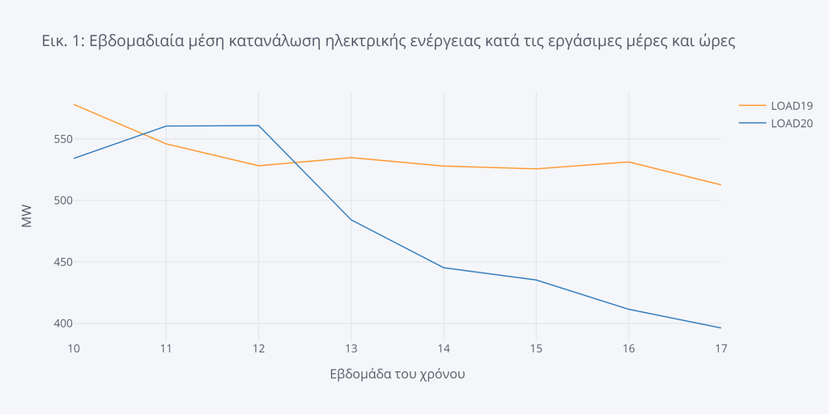

```python
alldfWmean = alldf[(alldf.index.hour >= 8) & (alldf.index.hour <= 18) & (alldf.index.weekday < 5) ].resample('W').mean()
alldfWmean['week'] = alldfWmean.index.weekofyear
alldfWmean.set_index('week', inplace=True)
fig = alldfWmean.iplot(asFigure = True, kind='line',y=['LOAD19','LOAD20'],xTitle='Εβδομάδα του χρόνου',yTitle='MW',title='Εικ. 1: Εβδομαδιαία μέση κατανάλωση ηλεκτρικής ενέργειας κατά τις εργάσιμες μέρες και ώρες')
if inPNG:
    fig.write_image("images/fig1.png", height = imheight, width = imwidth, scale = imscale)
    display(Image("images/fig1.png"))
else:
    fig.show()
```

Η Εικόνα 2 αντικατοπτρίζει τη μεταβολή στην κατανάλωση ηλεκτρικής ενέργειας σε σχέση με την αντίστοιχη εβδομάδα της περασμένης χρονιάς. Βλέπουμε ότι συνολικά καταγράφεται μια μείωση που αγγίζει το 20%. Αντίστοιχες μειώσεις [έχουν παρατηρηθεί και σε άλλες ευρωπαϊκές χώρες](https://infogram.com/electricity_line-1ho16v85mymx2nq) με την Ιταλία να έχει το αρνητικό ρεκόρ μείωσης μέχρι 38% ενώ οι [ΗΠΑ έχουν φτάσει σε ιστορικό χαμηλό 16 χρόνων](https://www.weforum.org/agenda/2020/04/united-states-eneregy-electricity-power-coronavirus-covid19/).

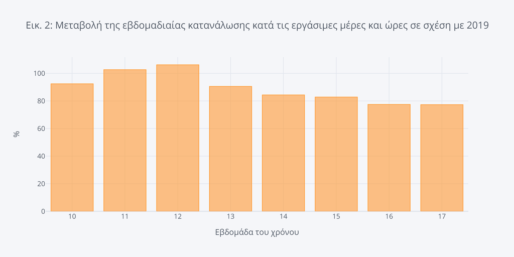

```python
alldfWmean['perc'] = (alldfWmean['LOAD20'] / alldfWmean['LOAD19'])*100.0
fig = alldfWmean.iplot(asFigure = True, kind='bar',xTitle='Εβδομάδα του χρόνου',yTitle='%',y='perc',title='Εικ. 2: Μεταβολή της εβδομαδιαίας κατανάλωσης κατά τις εργάσιμες μέρες και ώρες σε σχέση με 2019')
if inPNG:
    fig.write_image("images/fig2.png",height = imheight, width = imwidth, scale = imscale)
    display(Image("images/fig2.png"))
else:
    fig.show()
```

Αναντίλεκτα, υπάρχουν και άλλοι παράγοντες που επηρεάζουν την κατανάλωση ηλεκτρικής ενέργειας, με τον πιο κύριο να είναι οι θερμοκρασιακές μεταβολές που επηρεάζουν το φορτίο θέρμανσης. Οι "βαθμοημέρες" (heating degree days) είναι ένα μέτρο το οποίο δεικνύει για πόσους βαθμούς και για πόσες μέρες η εξωτερική θερμοκρασία είναι χαμηλότερη από μια συμβατική θερμοκρασία άνεσης. Μπορούν έτσι να χρησιμοποιηθούν για να προσαρμόσουν τη σύγκριση ανάμεσα σε διαφορετικά έτη. Για παράδειγμα, η Εικόνα 3 δείχνει τις εβδομαδιαίες βαθμοημέρες για την περίοδο που αναλύουμε. Αν επικεντρωθούμε στην 15η εβδομάδα (6-12 Απριλίου), στην οποία οι εβδομαδιαίες βαθμοημέρες ήταν ίδιες - και αντιστοιχεί σε εργάσιμη εβδομάδα- παρατηρούμε μια μείωση φορτίου 17% η οποία δεν μπορεί να αποδοθεί σε θερμοκρασιακές μεταβολές.

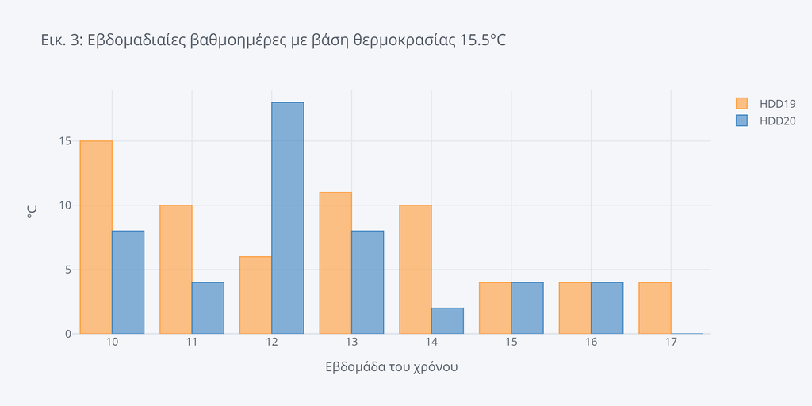

```python
allHDD['week'] = allHDD.index.weekofyear
allHDD.set_index('week', inplace=True)
fig = allHDD.iplot(asFigure = True, kind='bar',y=['HDD19','HDD20'],xTitle='Εβδομάδα του χρόνου',yTitle='°C',title='Εικ. 3: Εβδομαδιαίες βαθμοημέρες με βάση θερμοκρασίας 15.5°C')
if inPNG:
    fig.write_image("images/fig3.png",height = imheight, width = imwidth, scale = imscale)
    display(Image("images/fig3.png"))
else:
    fig.show()
```

Με τον εγκλεισμό μεγάλης μερίδας του πληθυσμού στο σπίτι, η οικιακή κατανάλωση έχει αναντίλεκτα αυξηθεί. Κατά συνέπεια, η συνολική μείωση η οποία παρατηρείται μπορεί να αποδοθεί με ασφάλεια στη μείωση οικονομικής δραστηριότητας στον εμπορικό, τουριστικό, και βιομηχανικό τομέα. Δυστυχώς, χωρίς περισσότερα στοιχεία για τη σύσταση και το είδος των δραστηριοτήτων, είναι δύσκολο να μεταφράσουμε αυτή τη μείωση της τάξης του 20% σε οικονομικούς δείκτες.

## Επίδραση στο χρόνο κατανάλωσης ηλεκτρικής ενέργειας

Εκτός από την ποσότητα ηλεκτρικής ενέργειας που καταναλώνεται, τα μέτρα έχουν επηρεάσει και τον χρόνο κατανάλωσης ηλεκτρικής ενέργειας. Κάθε άνοιξη το ημερήσιο ηλεκτρικό φορτίο στην Κύπρο χαρακτηρίζονται από δυο κορυφές (τοπικά μέγιστα). Η μία παρουσιάζεται το πρωί και η δεύτερη το βράδυ. Η Εικόνα 4 δείχνει το ηλεκτρικό φορτίο σε δύο εργάσιμες μέρες του Απριλίου.

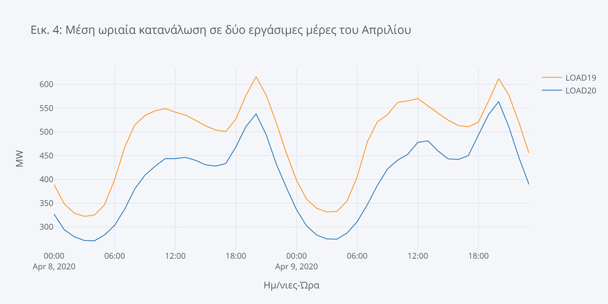

```python
fig = alldf[(alldf.index.dayofyear >= 99) & (alldf.index.dayofyear <= 100)].resample('H').mean().iplot(asFigure = True, kind='lines',y=['LOAD19','LOAD20'],xTitle='Ημ/νιες-Ώρα',yTitle='MW',title='Εικ. 4: Μέση ωριαία κατανάλωση σε δύο εργάσιμες μέρες του Απριλίου')
if inPNG:
    fig.write_image("images/fig4.png",height = imheight, width = imwidth, scale = imscale)
    display(Image("images/fig4.png"))
else:
    fig.show()
```

Ένα μεγάλο μέρος του πληθυσμού δουλεύει ή εκπαιδεύεται από το σπίτι. Αυτό το γεγονός αποτυπώνεται στις μετρήσεις σαν μια χρονική μεταβολή στην έναρξη της πρωινής ρουτίνας. Συγκεκριμένα, αναλύοντας τις εργάσιμες μέρες της περιόδου 16 Μαρτίου με 26 Απριλίου, παρατηρούμε ότι η πρωινή κορυφή έχει μετακινηθεί χρονικά σε σχέση με την αντίστοιχη περσινή περίοδο κατά μία περίπου ώρα πιο αργά (μέση τιμή πρωινής κορυφής). Η βραδινή κορυφή από την άλλη, που σχετίζεται κυρίως με οικιακές δραστηριότητες και ψυχαγωγία, παρουσιάζει μικρή μετατόπιση μερικών λεπτών.

Την ίδια εικόνα δίνουν και οι τυπικές καμπύλες φορτίου κατά τις εργάσιμες μέρες, που φαίνονται στην Εικόνα 5, και δείχνουν μια ξεκάθαρη μετατόπιση της πρωινής κατανάλωσης προς τις μεσημεριανές ώρες.

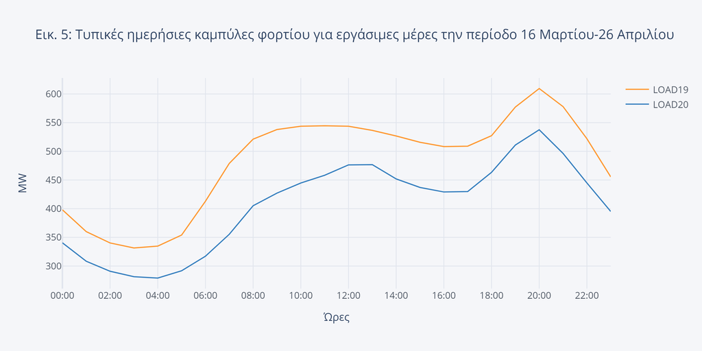

```python
import numpy as np
import datetime as dt
from sklearn.cluster import KMeans
from sklearn.preprocessing import MinMaxScaler

df_uci_init = alldf.copy(deep=True)
df_uci_init = df_uci_init[ (alldf.index.weekday < 5) ]
df_uci_init = df_uci_init.drop(['PEN19','TEMP19','PEN20','TEMP20'], axis=1)
years = ['LOAD19','LOAD20']
#print(df19wd,df20wd)
dbs = [df19wd.drop(['CAP','WIND','PV','CONV','PEN19','TEMP19'], axis=1),
       df20wd.drop(['CAP','WIND','PV','CONV','PEN20','TEMP20'], axis=1)]
first = True
for yr, df_uci  in zip(years,dbs):

    df_uci = df_uci.replace('?', np.nan)
    df_uci = df_uci.astype(np.float).fillna(method='bfill')

    df_uci_hourly = df_uci.resample('H').mean()
    df_uci_hourly['hour'] = df_uci_hourly.index.hour
    df_uci_hourly.index = df_uci_hourly.index.date

    df_uci_pivot = df_uci_hourly.pivot(columns='hour')
    df_uci_pivot = df_uci_pivot.dropna()

    X = df_uci_pivot.values.copy()

    # Very important to scale!
    sc = MinMaxScaler()
    X = sc.fit_transform(X)
    kmeans = KMeans(n_clusters=1)
    cluster_found = kmeans.fit_predict(X)
    cluster_found_sr = pd.Series(cluster_found, name='cluster')
    df_uci_pivot = df_uci_pivot.set_index(cluster_found_sr, append=True )

    cluster_values = sorted(df_uci_pivot.index.get_level_values('cluster').unique())

    if first:
        myfig = df_uci_pivot.xs(0, level=1).median().droplevel(level=0).iplot(asFigure = True)
        myfig.update_traces(name=yr,mode='lines',line=dict(width=1.5))
        first = False
    else:
        myfig.add_trace(go.Scatter(x=df_uci_pivot.xs(0, level=1).median().index.droplevel(level=0),y=df_uci_pivot.xs(0, level=1).median().values, mode='lines',name=yr,line=dict(width=1.5,color=cf.colors.hex_to_rgb('blue'))))

myfig.update_layout(title='Εικ. 5: Τυπικές ημερήσιες καμπύλες φορτίου για εργάσιμες μέρες την περίοδο 16 Μαρτίου-26 Απριλίου',
                   xaxis_title='Ώρες',
                   yaxis_title='MW',
                   xaxis = dict(tickmode = 'array',
                        tickvals=list(np.arange(0,24,2)),
                        ticktext = [ dt.time(i).strftime('%H:%M') for i in np.arange(0,24,2)]),
                   showlegend=True)
if inPNG:
    myfig.write_image("images/fig5.png",height = imheight, width = imwidth, scale = imscale)
    display(Image("images/fig5.png"))
else:
    myfig.show()
```

## Επιπτώσεις στο σύστημα ηλεκτρικής ενέργειας

Οι αλλαγές στην κατανάλωση ηλεκτρικής ενέργειας έχουν αναπόφευκτα επηρεάσει τη λειτουργία του συστήματος ηλεκτρικής ενέργειας. Η μειωμένη κατανάλωση, σε συνδυασμό με την αυξημένη παραγωγή από ανανεώσιμες πηγές ενέργειας (ΑΠΕ), λόγω της εποχής, έχουν δημιουργήσει πρωτοφανείς καταστάσεις για τα κυπριακά δεδομένα. Η Εικόνα 6 δείχνει την ωριαία διείσδυση ΑΠΕ σαν ποσοστό του συνολικού φορτίου στην οποία παρατηρείται μεγάλη αύξηση κατά την περίοδο 27 Μαρτίου με 6 Απριλίου, φτάνοντας το 54% στις 3 Απριλίου. Ταυτόχρονα, η συνολική κάλυψη ηλεκτρικής ενέργειας από ΑΠΕ την περίοδο 16 Μαρτίου-26 Απριλίου έφτασε το 18%. Σε συνδυασμό με τη μείωση εκπομπών διοξειδίου, αποτελεί ίσως τον μόνο θετικό δείκτη της πανδημίας.

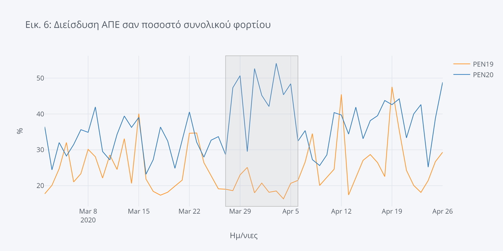

```python
fig = alldf.resample('D').max().iplot(asFigure = True,
    kind='lines',y=['PEN19','PEN20'],xTitle='Ημ/νιες',
    yTitle='%',title='Εικ. 6: Διείσδυση ΑΠΕ σαν ποσοστό συνολικού φορτίου',
    vspan={'x0':'2020-03-27','x1':'2020-04-06',
                      'color':'rgba(30,30,30,0.3)','fill':True,'opacity':.2})
if inPNG:
    fig.write_image("images/fig6.png",height = imheight, width = imwidth, scale = imscale)
    display(Image("images/fig6.png"))
else:
    fig.show()
```

Θα πρέπει όμως να σημειωθεί, ότι η αυξημένη διείσδυση από ΑΠΕ εξ υπακούει συνήθως μειωμένη παραγωγή από συμβατικές παραγωγικές μονάδες ορυκτών καυσίμων. Ενώ η αύξηση είναι φυσικά ευπρόσδεκτη από περιβαλλοντικής σκοπιάς, μπορεί ταυτόχρονα να δημιουργήσει τεχνικά προβλήματα στο δίκτυο ηλεκτρικής ενέργειας, του οποίου η ευσταθής λειτουργία και ο έλεγχος βασίζονται κυρίως στις συμβατικές μονάδες παραγωγής. Αυτή η προοπτική έχει απασχολήσει σοβαρά τη βιομηχανία και τα πανεπιστήμια τα τελευταία χρόνια, με έντονη ερευνητική δραστηριότητα κάτω από την ομπρέλα των προβλημάτων "χαμηλής αδράνειας". Το εργαστήριο Αειφόρων Συστημάτων Ισχύος στο ΤΕΠΑΚ έχει [εκτεταμένη έρευνα στο τομέα αυτό](https://sps.cut.ac.cy/project/low-inertia/).

Η ενεργειακή κατάσταση η οποία επικρατεί αυτή την περίοδο αποτελεί ένα παράθυρο στο μέλλον για τα πιθανά προβλήματα και τις λειτουργικές ανάγκες ενός συστήματος χαμηλής αδράνειας και ψηλής διείσδυσης ΑΠΕ, το οποίο σχεδιάζεται για την Κύπρο. Επιπλέον, αποτελεί απόδειξη ότι οι συνθήκες διείσδυσης που αναλύονταν μέχρι πρόσφατα σαν θεωρητικές ασκήσεις γίνονται πλέον πραγματικότητα. Παρόλες τις προκλήσεις, το Κυπριακό σύστημα ηλεκτρικής ενέργειας δείχνει να διατηρεί, επί του παρόντος, υψηλά επίπεδα αξιοπιστίας με ενθαρρυντικές ενδείξεις για την ικανότητα του να λειτουργήσει σαν σύστημα χαμηλής αδράνειας. Ίσως αυτές οι ενδείξεις να ενισχύσουν το πρόγραμμα μεταρρύθμισης του ηλεκτρικού συστήματος με έμφαση στην αειφόρο ανάπτυξη.

Από την άλλη, η ραγδαία μείωση στην κατανάλωση φορτίου έχει αρνητική επίδραση στο κόστος λειτουργίας των μονάδων παραγωγής καθώς καλούνται να παράγουν στα τεχνικά ελάχιστα ή ακόμη και να τεθούν εκτός λειτουργίας. Σε χώρες όπου λειτουργεί ανταγωνιστική αγορά ηλεκτρικής ενέργειας, έχει παρατηρηθεί πτώση των τιμών και η ζημιά επηρεάζει κυρίως τις συμβατικές μονάδες, καθώς οι ΑΠΕ έχουν χαμηλό ή μηδενικό οριακό κόστος παραγωγής. Στη Κύπρο, λόγο πιθανών προβλημάτων με την ευστάθεια του δικτύου, υπάρχει ελάχιστο όριο στη συμμετοχή συμβατικών μονάδων, κάτι που οδηγεί μερικές φορές στην περικοπή παραγωγής ηλεκτρικής ενέργειας από ΑΠΕ. Σύμφωνα με πληροφορίες, στην υπό αναφορά περίοδο, χρειάστηκε να γίνει τρεις φορές μείωση παραγωγής από ΑΠΕ στην Κύπρο για να διατηρηθεί η ευστάθεια του δικτύου.

## Επίλογος

Η πανδημία έχει δημιουργήσει μια νέα πραγματικότητα σε όλους τους τομείς της ζωής με κυρίως αρνητικό αντίκτυπο. Η κατανάλωση ενέργειας αποτυπώνει εν μέρει την επίπτωση αυτή και αποτελεί ένα δείκτη πραγματικού χρόνου που θα χαρτογραφήσει την επαναφορά σε κανονικούς ρυθμούς.

Παρόλα αυτά, στο τομέα της ενέργειας η πανδημία μας έδειξε ότι υπάρχει η δυνατότητα για ένα αειφόρο και αξιόπιστο σύστημα βασισμένο σε ΑΠΕ. Τα δίκτυα ηλεκτρικής ενέργειας βρίσκονται στην καρδιά της οικονομικής δραστηριότητας και θα αποτελέσουν πυλώνα για την επανεκκίνηση της οικονομίας. Είναι στο χέρι μας να διατηρήσουμε και να επενδύσουμε σε αειφόρο ενεργειακό σχεδιασμό για να διατηρήσουμε τους θετικούς περιβαλλοντικούς δείκτες και να προωθήσουμε την αειφόρο οικονομική ανάπτυξη.

Κλείνοντας, στη σελίδα του εργαστηρίου υπάρχει [εκτεταμένη βιβλιογραφία](https://sps.cut.ac.cy/project/low-inertia/) για την έρευνα του εργαστηρίου στο τομέα συστημάτων χαμηλής αδράνειας και επίλυσης προβλημάτων που σχετίζονται με τη διείσδυση ΑΠΕ.

### Βιογραφικό

Ο Δρ Πέτρος Αριστείδου είναι Λέκτορας στο Τεχνολογικό Πανεπιστήμιο Κύπρου. Είναι επικεφαλής του [Εργαστηρίου Αειφόρων Συστημάτων Ισχύος](https://sps.cut.ac.cy/) με έρευνα στην ευστάθεια, έλεγχο, και οικονομική λειτουργία συστημάτων ηλεκτρικής ενέργειας.

### Τεχνικές λεπτομέρειες

- Θα ήθελα να ευχαριστήσω το κ. Χρυσοβαλάντη Σπανιά (ΑΗΚ) για τα σχόλια και πληροφορίες σχετικά με τη διαχείριση ΑΠΕ στη Κύπρο.
- Η ενεργειακή ανάλυση βασίστηκε σε δεδομένα διαθέσιμα από τη σελίδα του [Διαχειριστή Συστήματος Μεταφοράς Κύπρου](https://tsoc.org.cy/). Η συνολική κατανάλωση περιλαμβάνει και τις απώλειες δικτύου ενώ η παραγωγή από φωτοβολταϊκές μονάδες είναι εκτιμώμενη τιμή και όχι μετρημένη.
- Τα μετεωρολογικά ληφθήκαν από τη σελίδα https://cy.freemeteo.com χρησιμοποιώντας μετρήσεις από σταθμούς αεροδρομίων.
- Οι ανάλυση δεδομένων και η απεικόνιση έγιναν με τα πακέτα pandas και plotly αντίστοιχα.
- Οι τυπικές ημερήσιες καμπύλες της Εικόνας 5 δημιουργήθηκαν με τη μέθοδο KMeans clustering και το πακέτο sklearn.
- Σαν εργάσιμες μέρες θεωρηθήκαν οι Δευτέρα με Παρασκευή, εκτός των εθνικών αργιών. Εργάσιμες ώρες θεωρηθήκαν 08:00-18:00.